# Multivariate Methods:

## Ordination and kmeans

#### Session 11: R-Peer-Group

### K-mean clustering

- kmeans is a simple method to identify clusters within data
- kmeans optimizes the partitioning of \( n \) individuals into \( k \) clusters
  - Clusters are defined by a multi-dimensional mean (**centroid**)
  - Individuals are assigned to clusters based on their proximity to  
    a clusters centroid
  - With group sum of squares distance from centroid is minimized

### K-means in 2 dimensions

#### randomly initialize for \( k = 2 \)

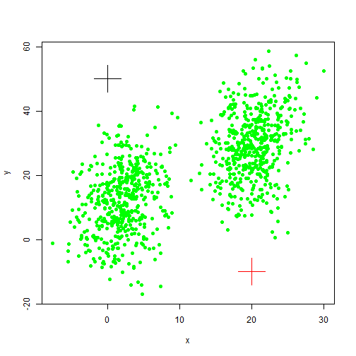

#### Identify point closest to each cluster centroid

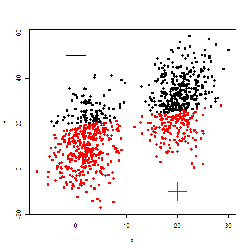

#### Assign individuals to centroids

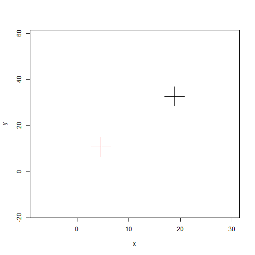

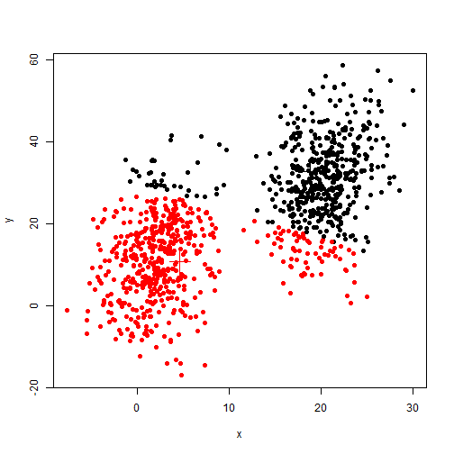

#### Reassign individuals to new centroids

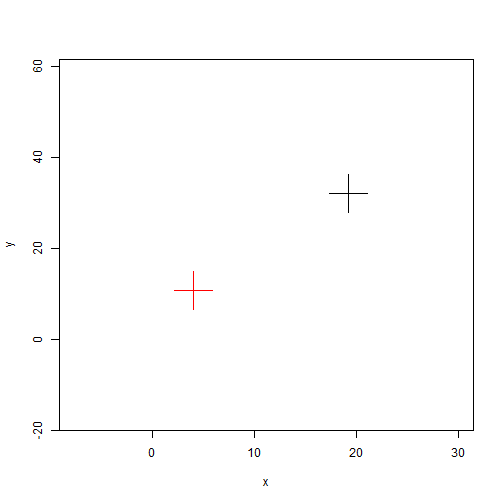

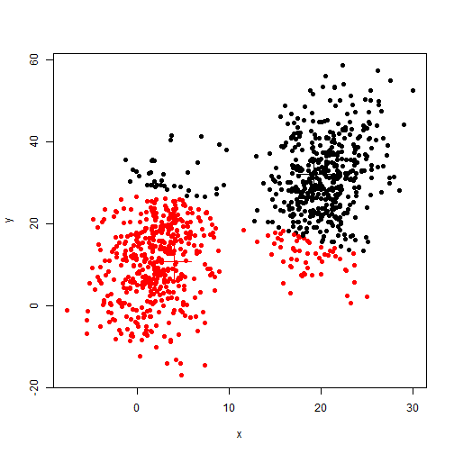

### K-means in 3 dimensions

#### Plot with centroids defined

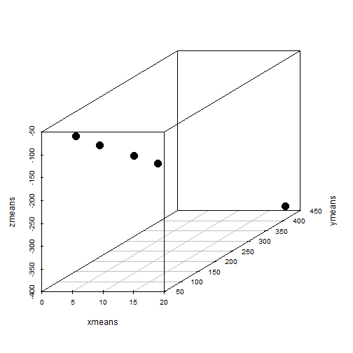

#### Plot data over centroids

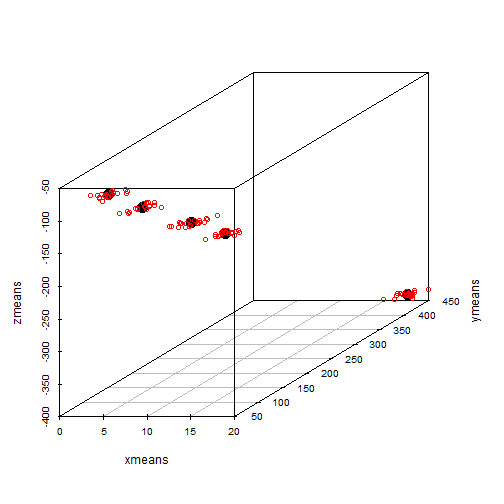

#### Test for the number of clusters (\( k \))

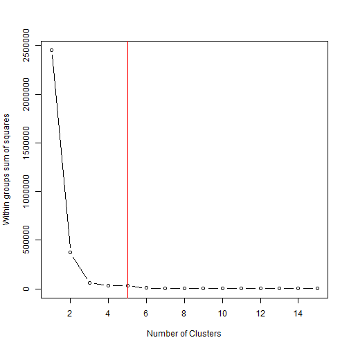

```r
# mydata is a dataframe test for k = 1:15
set.seed(10)
wsskk <- sapply(1:15, function(i) {
    return(sum(kmeans(mydata, centers = i, iter.max = 10000)$withinss))
})

plot(1:15, wsskk, type = "b", xlab = "Number of Clusters", ylab = "Within groups sum of squares")

abline(v = 5, col = "red")
```

# An example using real data

In this example we will use a data set collected by the United States Census  
Bureau. The data describes demographic changes in 51 states between 2000 and  
2001. An analyst is charged with identifying meaningful strucutre within the  
data to allow state legislators to understand how their policies might be affecting their population.

### First we test for the most likely value for \( k \)

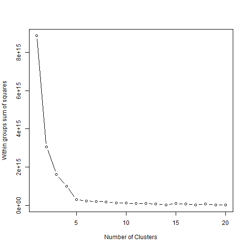

```r
# Read galaxy data
us_data <- read.delim("us_data.txt", header = TRUE)
set.seed(962520851)
usSS <- sapply(1:20, function(i) {
    return(sum(kmeans(us_data[, -1], centers = i, iter.max = 10000)$withinss))
})

plot(1:20, usSS, type = "b", xlab = "Number of Clusters", ylab = "Within groups sum of squares")
```

### Next we run `kmeans` for the choosen \( k \)

```r
usK <- kmeans(us_data[, -1], centers = 5, iter.max = 10000)
```

### Now we need to find some meaningful way to visualise the results

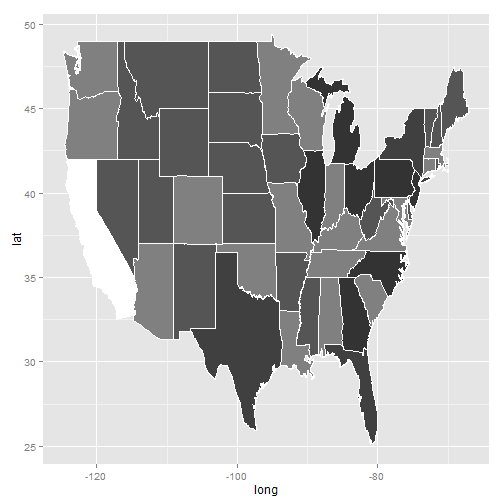

```r
# Try plotting a map
library("maps")
library("ggplot2")

# create a vector for colours
clust <- usK$cluster
names(clust) <- toupper(us_data[, 1])

# load US state data
states <- map_data("state")

clust_assign <- apply(states, 1, function(x) {
    return(clust[toupper(x[5])])
})


# plot the states plot all states with ggplot
p <- ggplot()
p <- p + geom_polygon(data = states, aes(x = long, y = lat, group = group),
    colour = "white", fill = gray(1/clust_assign))
p
```

# References

- Jain, A. K., Murty, M. N., & Flynn, P. J. (1999). Data clustering: a review.  
  ACM computing surveys (CSUR), 31(3), 264-323.
- Crawley, M. J. (2012). The R book. Wiley.
- Wickham, H. (2009). ggplot2: elegant graphics for data analysis. Springer  
  Publishing Company, Incorporated.

[figure not shown]

# Ordination analyses

- Attempts to describe multidimensional variance in lower dimensional space
- These lower dimensions become the axes of the plot and should summarise  
  the relationships between variables (sites, species or explanatory variables) in multivariate space
- These techniques are always based on an initial distance matrix between  
  samples/sites (e.g. Euclidean distance, chi sq distance, bray curtis distance)
- There are many techniques and metrics available today I will focus on  
  Principle Components Analysis (PCA -based on euclidean distance) and  
  corresponsdance analysis (CA - based on chi sq distance, suitable for  
  species data)

# Constrained ordination analyses

- Ordination space is constrained by explanatory variables  
  (i.e. axes of the new lower dimensional space are now combinations  
  predictors variables such as chemistry, habitat, invasion state etc.)
- P-values are permutation based
- Here I will discuss Canonical correspondance analysis (CCA) and extension  
  of (CA). Other commonly used approaches include RDA (an extension of PCA)  
  and permanova (which uses a bray curtis metric by default (function = adonis  
  in package “vegan”)

## References

- Bocard *et al* 2011, Numerical Ecology with R
- Oksanen (2011) Multivariate Analysis of Ecological Communities in R: vegan  
  tutorial (available online in pdf)